# Resolução da Lista de Exercícios 2

MPA - Discipplina: Introdução à Ciência dos Dados 2023

Prof. Washington S. Silva

20/06/2023

```r
# opcoes globais para o arquivo a ser gerado
knitr::opts_chunk$set(echo = TRUE, message = FALSE, warning = FALSE)
options(digits = 4, scipen = 999)

# pacotes utilizados
library(dplyr)
library(readr)
library(ggplot2)
library(ggthemes)
library(PerformanceAnalytics)
library(DescTools)
library(pwr)
```

## Preparação dos dados

Importando o arquivo `dados_franco2022.csv`:

```r
path <- "dados/dados_franco2022.csv"
dados <- read_csv(path)
glimpse(dados)
```

```
## Rows: 148
## Columns: 6
## $ data   <date> 2005-09-01, 2005-10-01, 2005-11-01, 2005-12-01, 2006-01-01, 20…
## $ EPU    <dbl> 90.70, 61.17, 152.60, 153.89, 140.05, 41.44, 126.21, 80.27, 95.…
## $ IEM    <dbl> 94.10, 92.60, 100.81, 91.29, 95.34, 89.98, 94.42, 91.27, 96.65,…
## $ INC    <dbl> 0.3813, 0.3573, 0.3911, 0.4171, 0.4137, 0.4613, 0.5023, 0.4669,…
## $ ICCFEC <dbl> 109.2, 107.7, 117.2, 130.2, 131.5, 138.0, 137.8, 132.4, 138.2, …
## $ ICCFGV <dbl> 87.1, 89.6, 88.4, 89.0, 95.7, 94.8, 93.0, 91.4, 90.4, 90.1, 90.…
```

Retirando a coluna `data`:

```r
dados_cor <- dados |> select(-data)
glimpse(dados_cor)
```

```
## Rows: 148
## Columns: 5
## $ EPU    <dbl> 90.70, 61.17, 152.60, 153.89, 140.05, 41.44, 126.21, 80.27, 95.…
## $ IEM    <dbl> 94.10, 92.60, 100.81, 91.29, 95.34, 89.98, 94.42, 91.27, 96.65,…
## $ INC    <dbl> 0.3813, 0.3573, 0.3911, 0.4171, 0.4137, 0.4613, 0.5023, 0.4669,…
## $ ICCFEC <dbl> 109.2, 107.7, 117.2, 130.2, 131.5, 138.0, 137.8, 132.4, 138.2, …
## $ ICCFGV <dbl> 87.1, 89.6, 88.4, 89.0, 95.7, 94.8, 93.0, 91.4, 90.4, 90.1, 90.…
```

## Questão 1

Reproduzingo a Fig. 1 de FRANCO (2022):

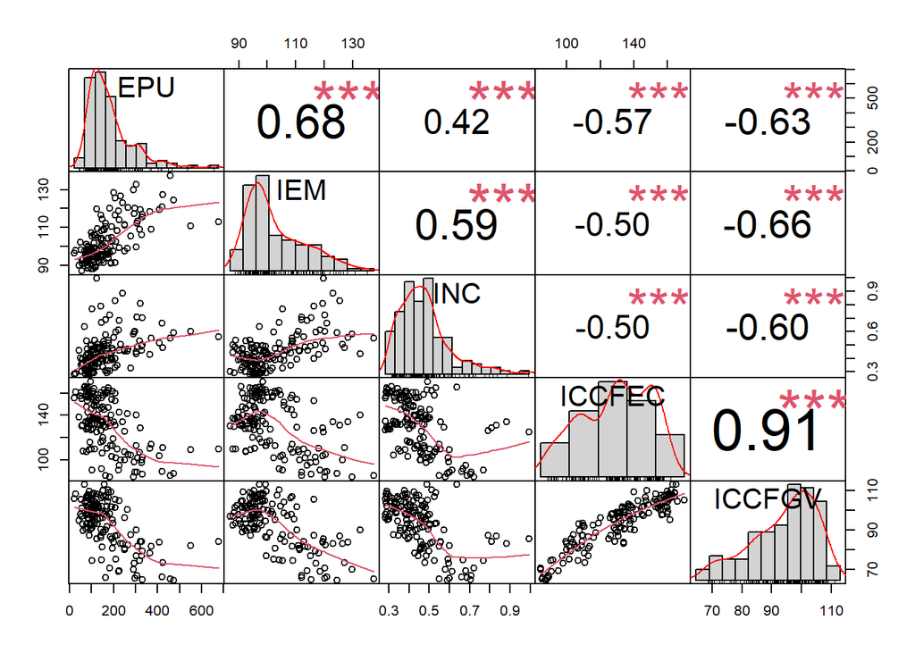

```r
chart.Correlation(dados_cor)
```

Os asteriscos associados às estimativas dos coeficientes de correlação entre os indicadores indicamo o nível de significância em que estas estimativas foram estatisticamente significativas, ou seja, estatisticamente diferentes de zero.

Todas as estimativas dos coeficientes de correlação entre os indicadores contém três asteriscos, o que indica que são estatificamente significativas a um nível de significância menor que 0.001 (ou 0,1%).

Podemos verificar o valor-p usando a função `cor.test`, vamos verificar o coeficiente de correlação de Spearman entre `ICCFGV` e `IEM`:

```r
cor.test(dados_cor$ICCFGV, dados_cor$IEM, alternative = "two.sided",
         method = "spearman")
```

```
##
##  Spearman's rank correlation rho
##
## data:  dados_cor$ICCFGV and dados_cor$IEM
## S = 818306, p-value = 0.00000000002
## alternative hypothesis: true rho is not equal to 0
## sample estimates:
##     rho
## -0.5146
```

```r
library(DescTools)
SpearmanRho(dados_cor$ICCFGV, dados_cor$IEM, conf.level = 0.95)
```

```
##     rho  lwr.ci  upr.ci
## -0.5146 -0.6241 -0.3853
```

O valor-p do teste de hipóeses foi igual a 0.00000000002, que é de fato menor que 0.001 (0.1%). Esta verificação poderia se estender aos coeficientes de correlação entre os outros indicadores.

## Questão 2

Os histogramas com densidades empíricas sobrepostas dos indicadores `EPU`, `IEM` e `INC` indicaram que a distribuição desses indicadores apresenta clara assimetria à direita (ou positiva), o que indica que não é razoável assumir uma distribuição normal para estes indicadores, neste caso, poderíamos utilizar o coeficiente de correlação de Spearman, que não exige que os dados sigam aproximadamente uma distribuição normal.

No caso do indicador `ICCFEC` podemos ver pelo menos dois picos ou modas no histograma, o que indica, pelo menos, bimodalidade da distribuição. Por sua vez, o histograma com densidade empírica sobreposta indica uma clara assimetria à esquerda (ou negativa). Em ambos os caos, novamente, não é razoável assumir que os dados desses indicadores poderiam ser modelados por, aproximadamente, por uma distribuição normal.

## Questão 3

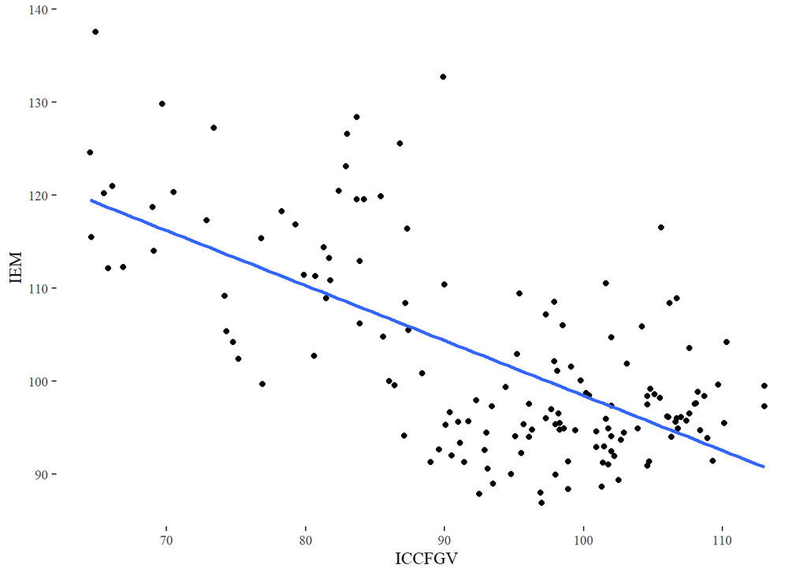

```r
ggplot(data = dados_cor, mapping = aes(x = ICCFGV, y = IEM)) +
  geom_point() +
  geom_smooth(method = "lm", se = FALSE) +
  labs(x = "ICCFGV", y = "IEM") +
  theme_tufte() +
  scale_color_colorblind()
```

O gráfico de dispersão evidencia uma clara correlação negativa, entre moderada e forte, entre o indicador de sentimento `ICCFGV` (índice de confiança do consumidor publicado pela Fundação Getulio Vargas) e o indicador de incerteza `IEM` (componente mídia do indicador de incerteza econômica IIE-BR, computado pelo Instituto Brasileiro de Economia (IBRE/FGV)).

## Questão 4

Os histogramas com densidades empíricas sobrepostas dos indicadores `ICCFGV` e `IEM`produzidos no item 2, indicaram que a distribuição de ambos os indicadores apresentam assimetria, o que indica que não é razoável assumir uma distribuição normal para estes indicadores, neste caso, como vimos, podemos utilizar procedimentos de inferência não-paramétricos (teste de hipótese e estimativa por intervalo de confiança) usando o coeficiente de correlação de Spearman, que não exige que os dados sigam uma distribuição aproximadamente normal:

```r
cor.test(dados_cor$ICCFGV, dados_cor$IEM, alternative = "two.sided",
         method = "spearman")
```

```
##
##  Spearman's rank correlation rho
##
## data:  dados_cor$ICCFGV and dados_cor$IEM
## S = 818306, p-value = 0.00000000002
## alternative hypothesis: true rho is not equal to 0
## sample estimates:
##     rho
## -0.5146
```

```r
library(DescTools)
SpearmanRho(dados_cor$ICCFGV, dados_cor$IEM, conf.level = 0.95)
```

```
##     rho  lwr.ci  upr.ci
## -0.5146 -0.6241 -0.3853
```

## Questão 5

Podemos utilizar a função `cohen.ES()` do pacote `pwr` para relembrar o que seria um tamanho de efeito (diferença) pequena segundo COHEN (1988):

```r
cohen.ES(test = "r", size = "small")
```

```
##
##      Conventional effect size from Cohen (1982)
##
##            test = r
##            size = small
##     effect.size = 0.1
```

Assim, devemos utilizar r = 0.1 como representando um pequeno tamanho do efeito (ou diferença) na função `pwr.r.test`:

```r
pwr.r.test(r = 0.1, n = 148, sig.level = 0.05, alternative = "two.sided")
```

```
##
##      approximate correlation power calculation (arctangh transformation)
##
##               n = 148
##               r = 0.1
##       sig.level = 0.05
##           power = 0.2278
##     alternative = two.sided
```

## Referências

COHEN, J. **Statistical power analysis for the behavioral sciences**. [s.l.] Lawrence Erlbaum Associates, 1988.

FRANCO, D. DE M. [Expectativas, Incerteza Econômica e Sentimento](https://rac.anpad.org.br/index.php/rac/article/view/1524/1767). **Revista de Administração Contemporânea**, v. 26, 2022.